# Consumer Behavior & Delivery Analytics: A Swiggy Dataset Exploration

# 🚚 Problem Statement: Average Delivery Time by City

Efficient delivery is a critical factor for customer satisfaction in food delivery platforms like Swiggy.  
Long delivery times can lead to lower ratings, decreased repeat orders, and loss of customers to competitors.

**Objective:**

- To analyze the average delivery time across different cities.
- Identify cities with faster or slower delivery times to understand operational bottlenecks and performance gaps.

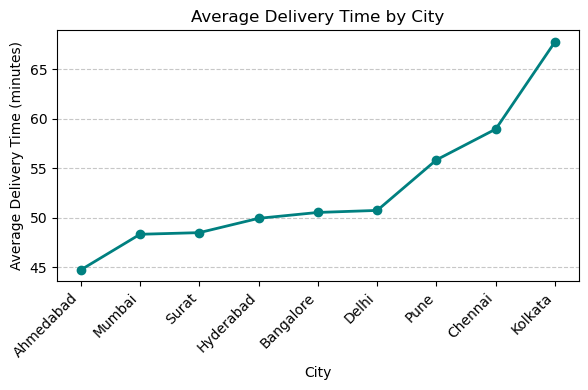

```python
# Group the dataset by 'City' and calculate the average delivery time

city_delivery = df.groupby('City')['Delivery time'].mean().sort_values()

# Plot the results as a line chart

city_delivery.plot(
    kind='line',
    marker='o',                  # Adds markers to each data point
    color='teal',
    linewidth=2,
    figsize=(6, 4),
    title='Average Delivery Time by City'
)

# Add axis labels and styling

plt.xlabel('City')
plt.ylabel('Average Delivery Time (minutes)')
plt.xticks(rotation=45, ha='right')
plt.grid(axis='y', linestyle='--', alpha=0.7)
plt.tight_layout()
plt.show()
```

# 🔑 Business Insights

1. **Faster Delivery Cities**
   - Cities with the lowest average delivery times demonstrate stronger logistics efficiency.
   - These cities can serve as benchmarks for operational best practices.
2. **Slower Delivery Cities**
   - Higher delivery times may indicate challenges such as:
     - Traffic congestion
     - Insufficient delivery fleet
     - Higher order density compared to available resources
3. **Actionable Recommendations**
   - Optimize delivery partner allocation in slower cities.
   - Improve restaurant–delivery partner coordination.
   - Introduce predictive analytics to manage high-demand times efficiently.
   - Learn from the top-performing cities and replicate their strategies in underperforming ones.
4. **Business Impact**
   - Reducing average delivery time by even 5–10 minutes can significantly boost:
     - **Customer retention**
     - **Repeat orders**
     - **Overall ratings**

# 🏁 Overall Takeaways & Recommendations – Swiggy Dataset Analysis

## 💡 Recommendations to Improve Sales in Upcoming Areas

1. **Localize Restaurant Partnerships**
   - Onboard restaurants offering **popular cuisines** for the area based on customer preferences.
   - Fill cuisine gaps in underserved neighborhoods to attract more customers.
2. **Optimize Delivery Logistics**
   - Allocate **more delivery partners** in areas with higher delivery times to improve customer experience.
   - Use predictive delivery routing to reduce time during peak hours.
3. **Promotional Campaigns**
   - Promote **top-rated restaurants or cuisines** in new areas to build awareness.
   - Offer **discounts or combo deals** in new areas to encourage trial orders.
4. **Data-Driven Marketing**
   - Target customers based on **city-specific and area-specific trends**.
   - Highlight **top cuisines or popular restaurants** in digital campaigns.
5. **Monitor Area Performance**
   - Continuously track **ratings, delivery time, and order volumes** in new areas.
   - Quickly identify areas with **low satisfaction** and implement corrective measures.
6. **Customer Engagement**
   - Encourage reviews and ratings in newly launched areas to **build credibility quickly**.
   - Offer loyalty programs or incentives for repeat orders.

✅ **In short:**  
By combining **area-level insights, cuisine preferences, and delivery efficiency**, Swiggy can **strategically launch in new areas**, optimize operations, and drive higher sales while improving customer satisfaction.